# Fuel Voltage Analysis

## Analysing Fuel Voltage Signal Data

```python
import numpy as np
import pandas as pd
from scipy.signal import butter, lfilter, freqz
from scipy import signal as sg
import matplotlib.pyplot as plt
from scipy.fftpack import fft

%matplotlib inline
```

#### Loading data in Pandas Dataframe

```python
df = pd.read_excel("Problem statement.xlsx")
df.info()
```

```
<class 'pandas.core.frame.DataFrame'>
RangeIndex: 33070 entries, 0 to 33069
Data columns (total 4 columns):
Timestamp              33070 non-null datetime64[ns]
Speed                  33070 non-null float64
Cumulative Distance    33070 non-null int64
Fuel Level (mV)        33070 non-null int64
dtypes: datetime64[ns](1), float64(1), int64(2)
memory usage: 1.0 MB
```

```python
df.describe()
```

|  | Speed | Cumulative Distance | Fuel Level (mV) |
| --- | --- | --- | --- |
| count | 33070.000000 | 3.307000e+04 | 33070.000000 |
| mean | 27.298125 | 2.192976e+06 | 613.757121 |
| std | 13.459000 | 1.018111e+06 | 69.923635 |
| min | 0.100000 | 0.000000e+00 | 0.000000 |
| 25% | 17.400000 | 1.380314e+06 | 589.000000 |
| 50% | 28.700000 | 2.189484e+06 | 614.000000 |
| 75% | 37.500000 | 3.077728e+06 | 651.000000 |
| max | 65.000000 | 3.937774e+06 | 758.000000 |

```python
df.head(10)
```

|  | Timestamp | Speed | Cumulative Distance | Fuel Level (mV) |
| --- | --- | --- | --- | --- |
| 0 | 2018-01-21 17:14:05 | 0.1 | 0 | 651 |
| 1 | 2018-01-21 17:15:06 | 3.8 | 25 | 646 |
| 2 | 2018-01-21 17:15:20 | 5.5 | 41 | 641 |
| 3 | 2018-01-21 17:15:23 | 6.2 | 46 | 641 |
| 4 | 2018-01-21 17:15:39 | 15.7 | 88 | 641 |
| 5 | 2018-01-21 17:15:41 | 16.1 | 96 | 641 |
| 6 | 2018-01-21 17:16:11 | 26.1 | 280 | 628 |
| 7 | 2018-01-21 17:16:41 | 23.8 | 474 | 619 |
| 8 | 2018-01-21 17:17:11 | 23.8 | 682 | 621 |
| 9 | 2018-01-21 17:17:41 | 27.0 | 893 | 619 |

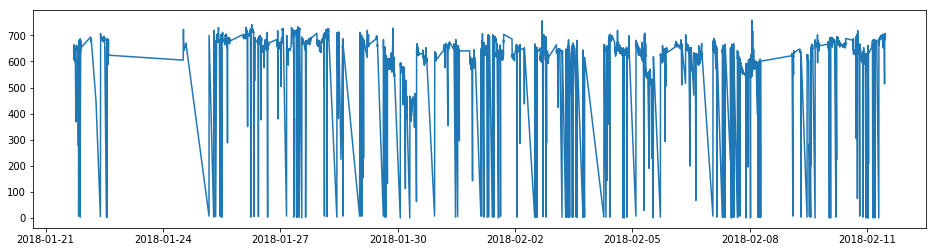

```python
plt.plot(df.Timestamp, df['Fuel Level (mV)'])
plt.rcParams['figure.figsize'] = [16,4]
```

The above line plot donot give a clear picture, about where the maximum datapoints are located. The give a better picture, we will use Box plot and scatter plot, that will help us in analysing where most of the data points are situated.

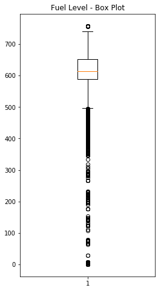

```python
plt.boxplot(df['Fuel Level (mV)']);
plt.title('Fuel Level - Box Plot');
plt.rcParams['figure.figsize'] = [4,8];
```

Above box plot data shows that the majority of data points lie between the value 500 and 700. All points below value are outliers and can be contributed to noise. The scatter plot for the 'Fuel Voltage' confirms the same.

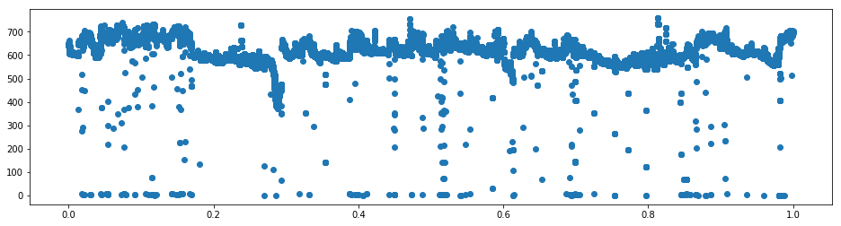

```python
plt.scatter(np.linspace(0,1, len(df)), df['Fuel Level (mV)'] );
plt.rcParams['figure.figsize'] = [16,4]
```

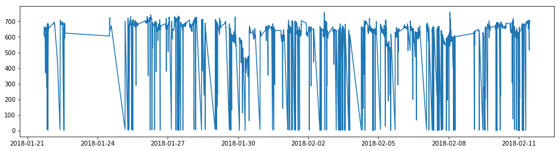

```python
plt.plot(df.Timestamp, df['Fuel Level (mV)'])
plt.rcParams['figure.figsize'] = [16,4]
```

Hense the above plot has inherent noise in it. This can be removed using Butterworth filter. But before that, it is important to analysis the Spectral plot of the voltage signal, in order to know the range and magnitude of noise frequency.

### Spectral Analysis - Plotting FFT

FFT will help in understanding the different frequency components available in the voltage signal in the form of noise.

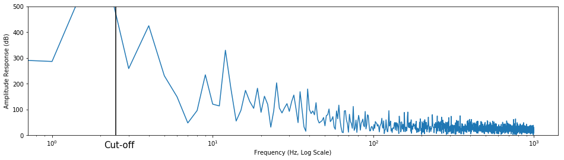

```python
yvolt = fft(norm_data)
plt.ylim(0,500);
plt.plot(np.abs(yvolt[:1000]));
plt.rcParams['figure.figsize'] = [16,4]
plt.xscale('log')
plt.ylabel('Amplitude Response (dB)')
plt.xlabel('Frequency (Hz, Log Scale)')
plt.axvline(2.5, color = 'black')
plt.text(2.1,-50, "Cut-off", fontsize = 15);
```

Hence most dominant frequency magnitudes are between 1-3 Hz signal, i.e. almost a DC signal. Remaining all are noise in the system. All these noise can be removed using a low-pass butterworth filter. Hence our cut-off frequency will be 2.5Hz

### SIgnal Filteration

This block defines the lowpass butterworth filter to be used for extracting true signal

```python
def butter_lowpass_filter(data, cutoff, fs, order=5, ftype = False):
    nyq = 0.5 * fs
    normal_cutoff = cutoff / nyq
    b, a = butter(order, normal_cutoff, btype='low', analog=ftype)
    y = lfilter(b, a, data)
    y1 = sg.filtfilt(b,a, data)
    return y,y1
```

### Results

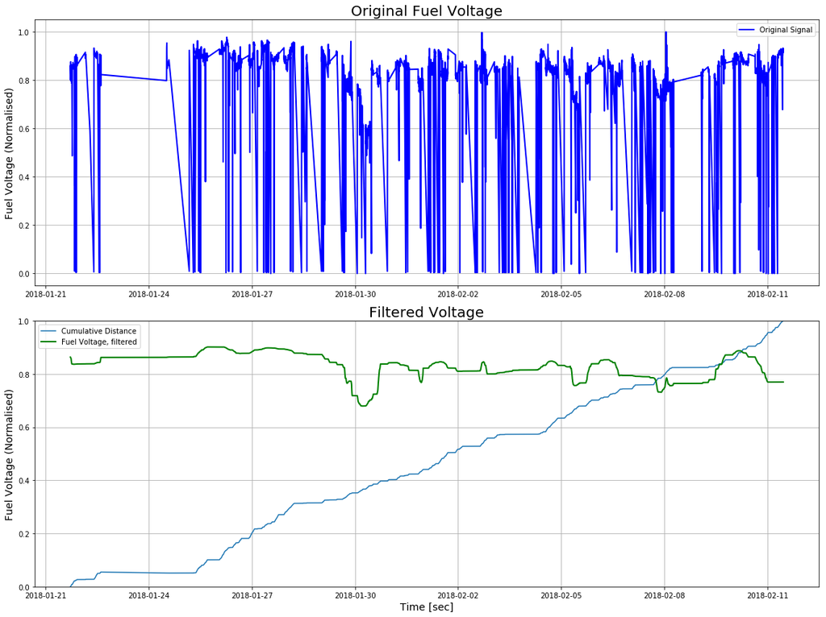

```python
# Filter the data, and plot both the original and filtered signals.
fs = 4000             # Sampling Frequency
order = 5             # Order of Filter
cutoff = 2.5          # Filter Cut-off Frequency

# Calling Butterworth filter
y,y1 = butter_lowpass_filter(norm_data, cutoff, fs, order, ftype= False)

time = df['Timestamp']

#Plotting Results
plt.subplot(2, 1,1)
plt.plot(time, norm_data, 'b-', linewidth=2, label='Original Signal')

plt.legend()
plt.grid()
plt.ylabel('Fuel Voltage (Normalised)',  fontsize = 14)
plt.title('Original Fuel Voltage', fontsize = 20)

plt.subplot(2, 1,2)
plt.plot(time, df['Cumulative Distance']/df['Cumulative Distance'].max(), label='Cumulative Distance');
plt.legend()
plt.twinx()
plt.ylabel('Cumulative Distance (Normalised)',  fontsize = 14)

plt.subplot(2, 1,2)
plt.plot(df.Timestamp, y1, 'g-', linewidth=2, label='Fuel Voltage, filtered')
plt.ylim(0,1)
plt.grid()
plt.legend()
plt.ylabel('Fuel Voltage (Normalised)',  fontsize = 14)
plt.title('Filtered Voltage', fontsize = 20)
plt.xlabel('Time [sec]',  fontsize = 14)






plt.tight_layout()
plt.rcParams['figure.figsize'] = [16,12]
```